# limiares

#### Allegro

0.1 [1] “

( janela 24 semanas, iteracao de 4 semanas) [1] “

#### Allegro

0.2 [1] “

( janela 24 semanas, iteracao de 4 semanas) [1] “

#### Allegro

0.3 [1] “

( janela 24 semanas, iteracao de 4 semanas) [1] “

#### Allegro

0.4 [1] “

#### Evolução dos desenvolvedores ao longo do tempo para cada nivel de conhecimento

( janela 24 semanas, iteracao de 4 semanas) [1] “

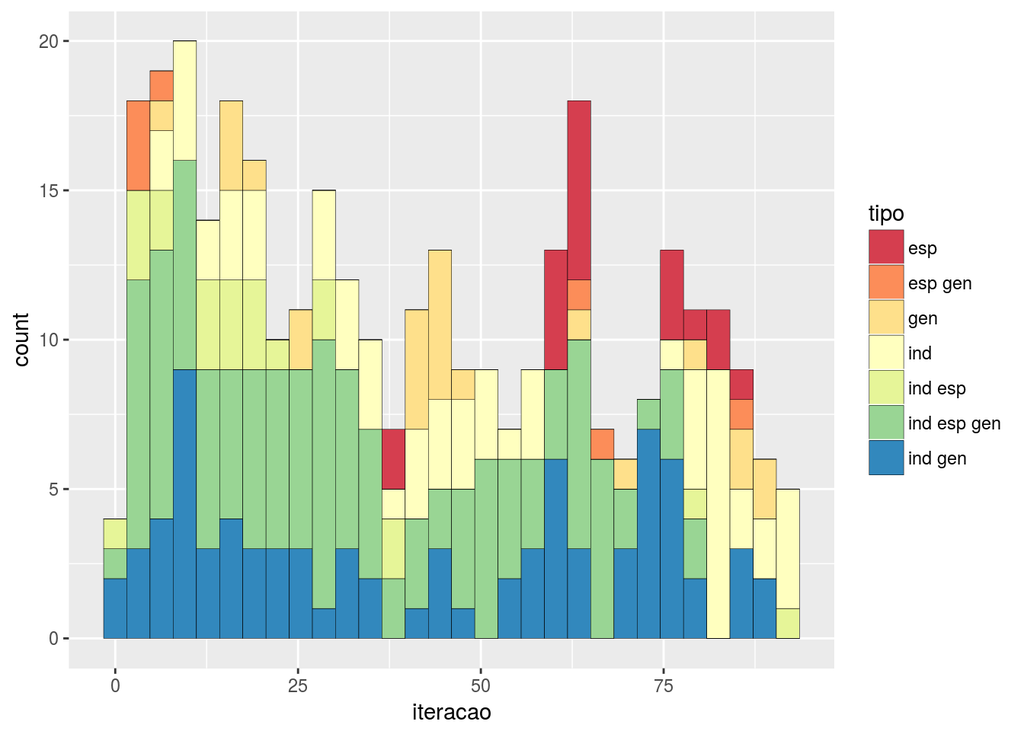

#### Allegro

0.5 [1] “

#### Evolução dos desenvolvedores ao longo do tempo para cada nivel de conhecimento

( janela 24 semanas, iteracao de 4 semanas) [1] “

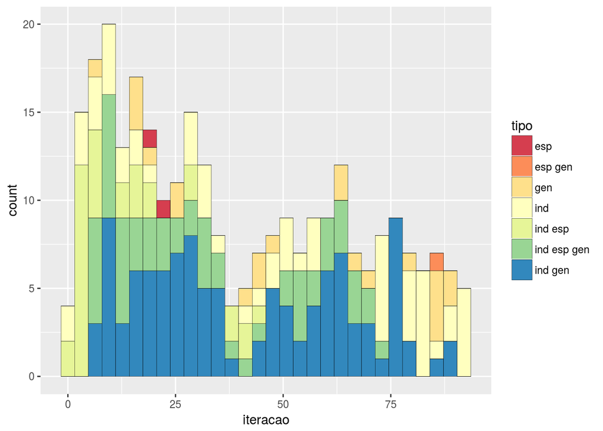

#### Allegro

0.6 [1] “

#### Evolução dos desenvolvedores ao longo do tempo para cada nivel de conhecimento

( janela 24 semanas, iteracao de 4 semanas) [1] “

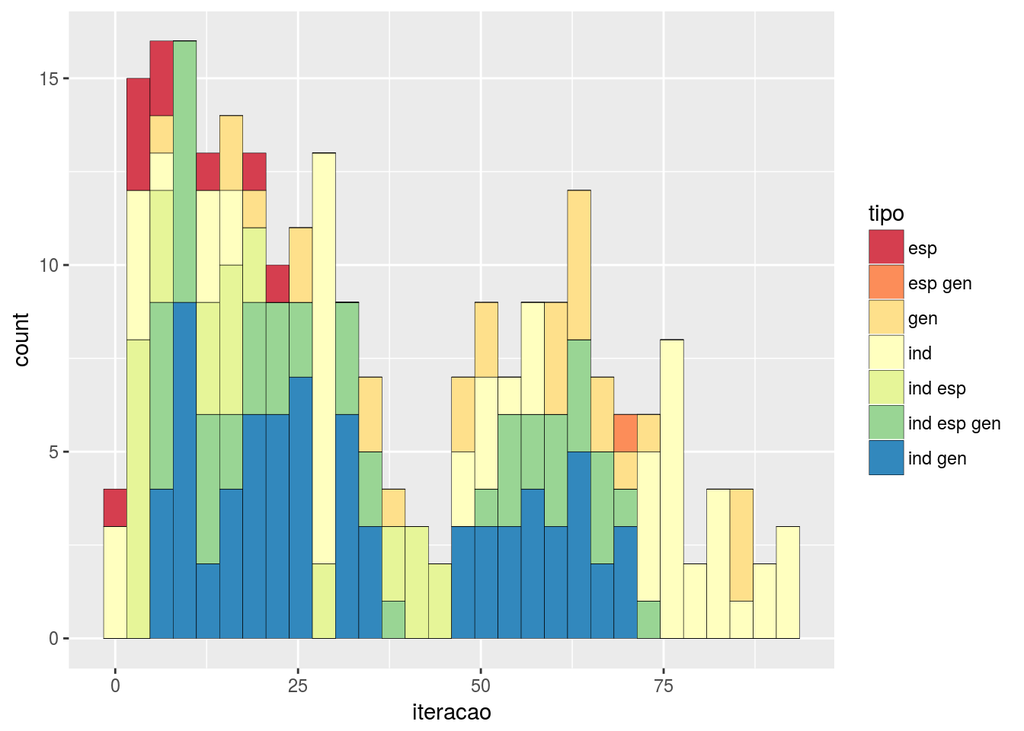

#### Allegro

0.7 [1] “

( janela 24 semanas, iteracao de 4 semanas) [1] “

#### SDL

0.1 [1] “

( janela 24 semanas, iteracao de 4 semanas) [1] “

#### SDL

0.2 [1] “

#### Evolução dos desenvolvedores ao longo do tempo para cada nivel de conhecimento

( janela 24 semanas, iteracao de 4 semanas) [1] “

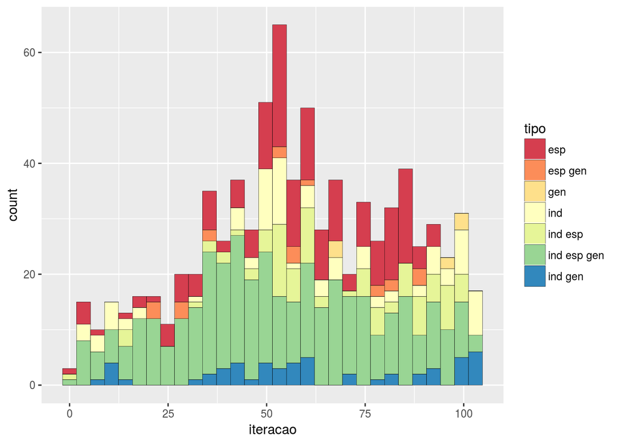

#### SDL

0.3 [1] “

#### Evolução dos desenvolvedores ao longo do tempo para cada nivel de conhecimento

( janela 24 semanas, iteracao de 4 semanas) [1] “

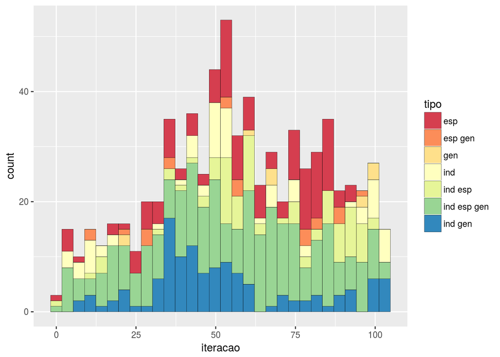

#### SDL

0.4 [1] “

#### Evolução dos desenvolvedores ao longo do tempo para cada nivel de conhecimento

( janela 24 semanas, iteracao de 4 semanas) [1] “

[figure not shown]

#### SDL

0.5 [1] “

#### Evolução dos desenvolvedores ao longo do tempo para cada nivel de conhecimento

( janela 24 semanas, iteracao de 4 semanas) [1] “

[figure not shown]

#### SDL

0.6 [1] “

#### Evolução dos desenvolvedores ao longo do tempo para cada nivel de conhecimento

( janela 24 semanas, iteracao de 4 semanas) [1] “

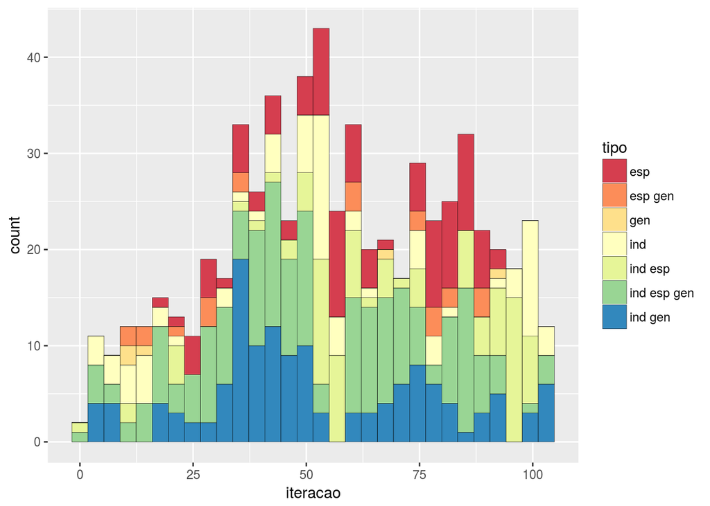

#### SDL

0.7 [1] “

#### Evolução dos desenvolvedores ao longo do tempo para cada nivel de conhecimento

( janela 24 semanas, iteracao de 4 semanas) [1] “

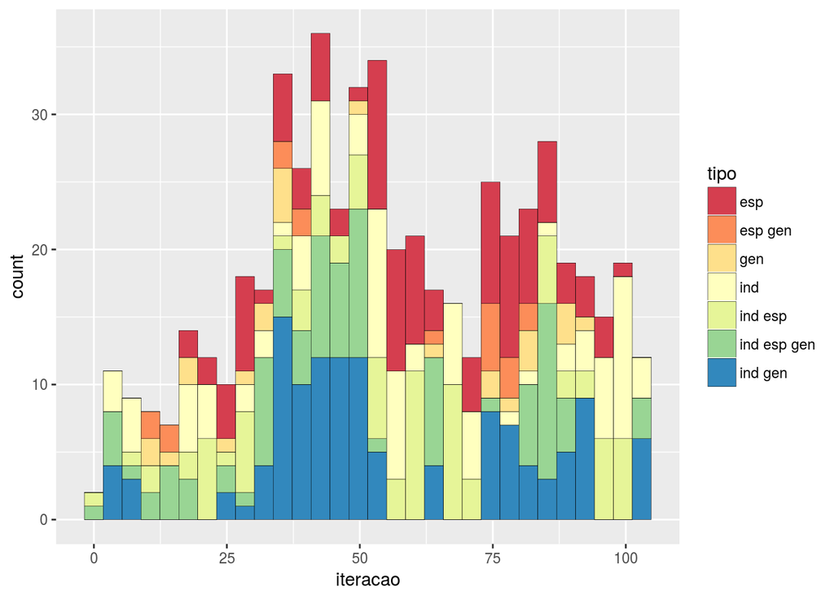

#### SFML

0.1 [1] “

( janela 24 semanas, iteracao de 4 semanas) [1] “

#### SFML

0.2 [1] “

( janela 24 semanas, iteracao de 4 semanas) [1] “

#### SFML

0.3 [1] “

#### Evolução dos desenvolvedores ao longo do tempo para cada nivel de conhecimento

( janela 24 semanas, iteracao de 4 semanas) [1] “

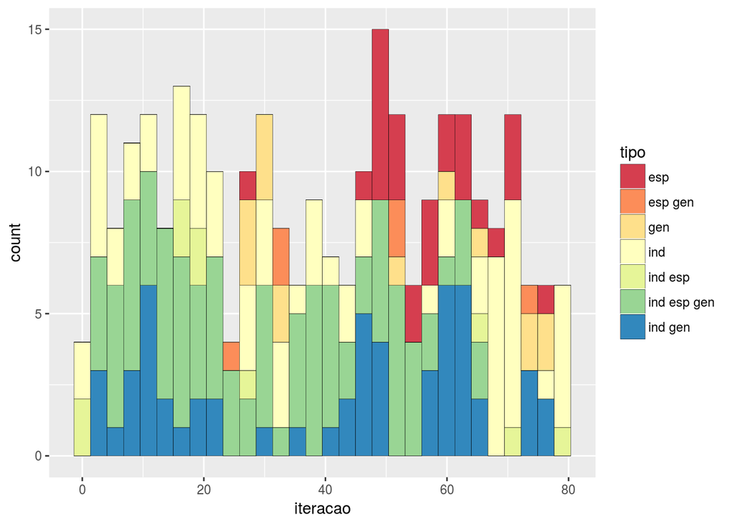

#### SFML

0.4 [1] “

#### Evolução dos desenvolvedores ao longo do tempo para cada nivel de conhecimento

( janela 24 semanas, iteracao de 4 semanas) [1] “

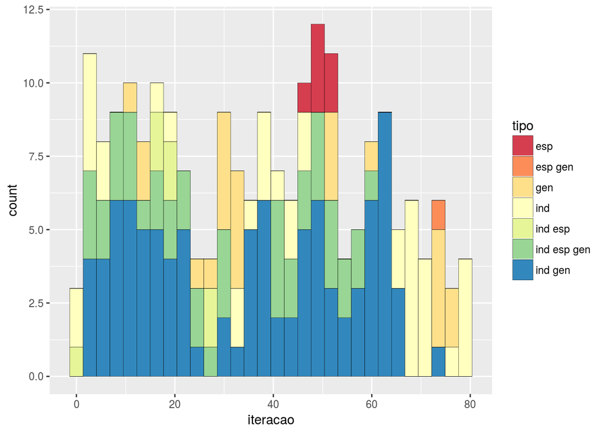

#### SFML

0.5 [1] “

( janela 24 semanas, iteracao de 4 semanas) [1] “

#### SFML

0.6 [1] “

#### Evolução dos desenvolvedores ao longo do tempo para cada nivel de conhecimento

( janela 24 semanas, iteracao de 4 semanas) [1] “

[figure not shown]

#### SFML

0.7 [1] “

( janela 24 semanas, iteracao de 4 semanas) [1] “

#### Coco2dx

0.1 [1] “

( janela 24 semanas, iteracao de 4 semanas) [1] “

#### Coco2dx

0.2 [1] “

#### Evolução dos desenvolvedores ao longo do tempo para cada nivel de conhecimento

( janela 24 semanas, iteracao de 4 semanas) [1] “

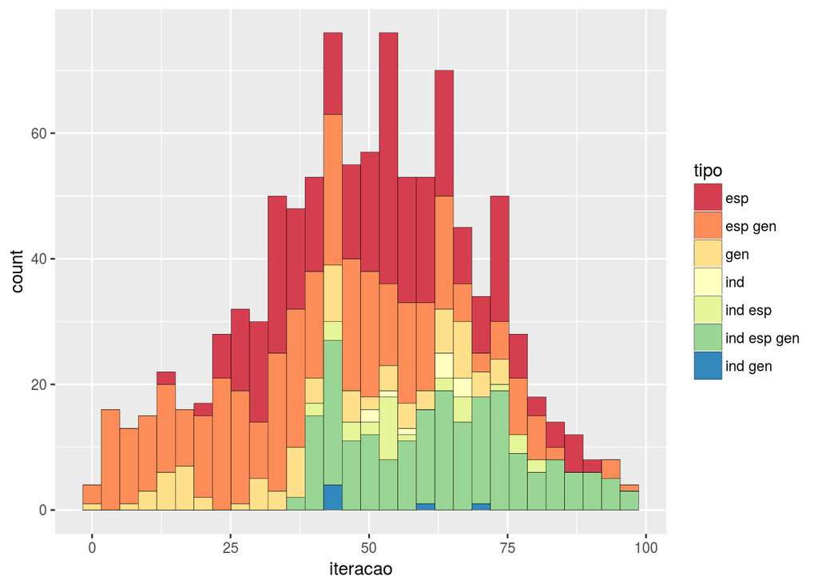

#### Coco2dx

0.3 [1] “

#### Evolução dos desenvolvedores ao longo do tempo para cada nivel de conhecimento

( janela 24 semanas, iteracao de 4 semanas) [1] “

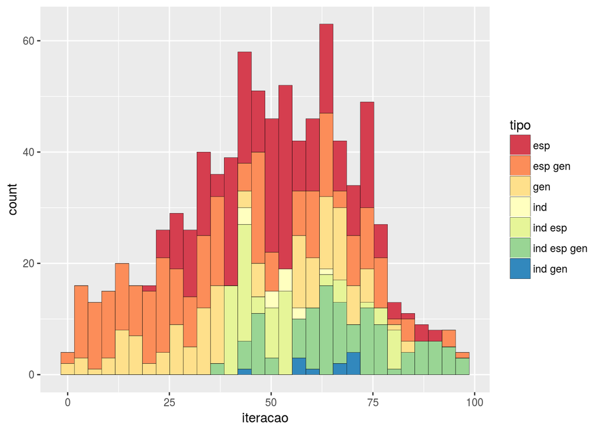

#### Coco2dx

0.4 [1] “

#### Evolução dos desenvolvedores ao longo do tempo para cada nivel de conhecimento

( janela 24 semanas, iteracao de 4 semanas) [1] “

[figure not shown]

#### Coco2dx

0.5 [1] “

#### Evolução dos desenvolvedores ao longo do tempo para cada nivel de conhecimento

( janela 24 semanas, iteracao de 4 semanas) [1] “

[figure not shown]

#### Coco2dx

0.6 [1] “

#### Evolução dos desenvolvedores ao longo do tempo para cada nivel de conhecimento

( janela 24 semanas, iteracao de 4 semanas) [1] “

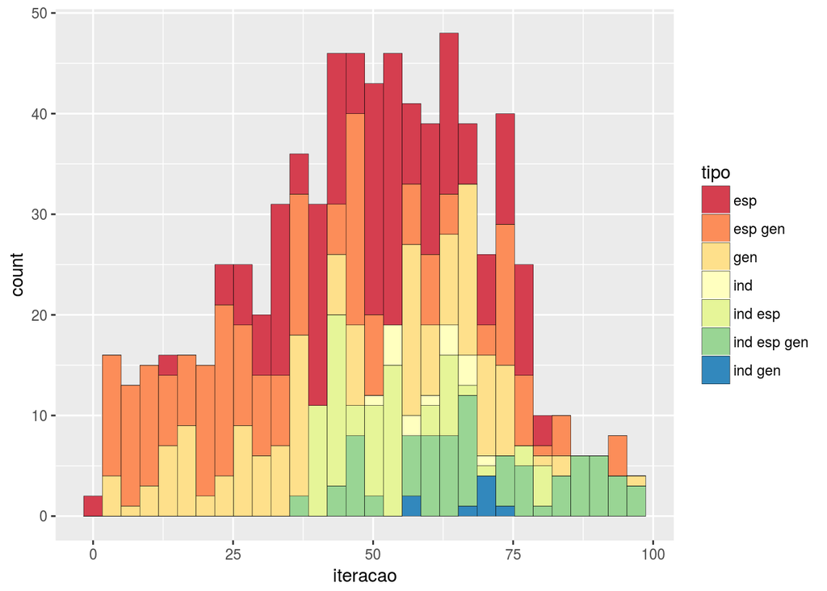

#### Coco2dx

0.7 [1] “

#### Evolução dos desenvolvedores ao longo do tempo para cada nivel de conhecimento

( janela 24 semanas, iteracao de 4 semanas) [1] “

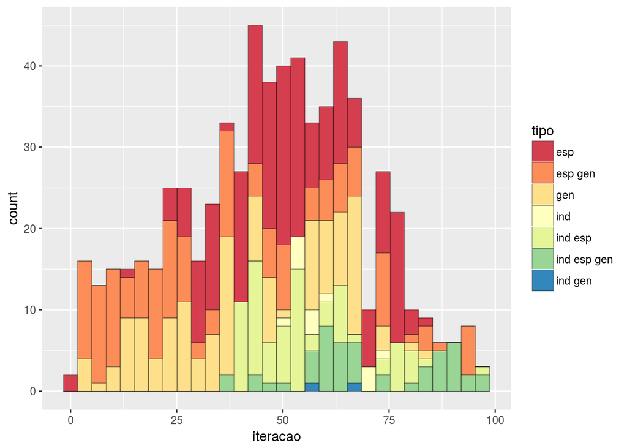